# Final Paper

STOR 320.02 Group 3 - Alexa Penwell, completed individually

Spring Semester 2020

# INTRODUCTION

Are certain countries more free than others? The Human Freedom Index strives to answer this question by collecting data about personal, civil, and economic liberties from all around the world. Freedom is defined here as negative liberty or the absence of coercive constraint. In order to evaluate the freedom of given countries, certain variables stood out to me as worth investigating. The first of these variables is Human Freedom Rank, named hf_rank in the dataset. This variable assesses freedom indices between countries to determine a rank of overall freedom, with a lower rank indicating more freedom. Since this variable is a great comparison variable between the countries, I decided to analyze the following question: “Can we predict whether a country is at war based on rank change data and other indices?”

This question regarding predicting at war status is interesting to explore because the general population would probably have the hypothesis that a country not at war would have more free citizens than a country that’s at war. Although this seems like a plausible hypothesis, it would be interesting to check the validity of this hypothesis. Contrary to this hypothesis, a country at war could decrease unemployment rates due to the need for workers to manufacture weapons and other materials, which could potentially lead to higher economic freedom with more cash in the hands of the working class. The rank change indices should reflect our hypothesis if it is correct. If a country is at war, we should expect to see a positive rank change value, indicating a decrease in overall freedom in comparison to other countries. Conversely, a negative rank change value would indicate a country not at war, given our hypothesis. Through the use of freedom indicators, we will be able to formulate a response to the accuracy of this proposed hypothesis.

The second question I decided to explore further is “What factors influence the difference between women’s freedom scores and the overall population’s freedom scores in this index?” The extent that women have certain rights has always been used as an indicator of how progressive a country is. Some of the milestones in women’s path to equality have been the right to vote, the right of equal employment, and the right to own property. However, not all countries are at the level yet where these rights, which seem common sense to us in some parts of the world, are given to all citizens. Because of this difference across the world, investigating women’s freedom scores specifically could lead us to some interesting, and potentially unexpected, conclusions about what factors influence women’s freedom, or lack thereof.

# DATA

The CATO Institute along with the Fraser Institute and the Liberales Institute at the Friedrich Naumann Foundation for Freedom co-published the Human Freedom Index (HFI). In order to remain as objective as possible, these companies selected data from credible external sources and included their methodology and sources in the write up of their project. The creation of this type of index of freedom is important because multiple types of freedom are evaluated together, rather than each on their own. Democratic/political freedom is excluded from this information since the methodology of how to best determine this indice is still being researched. In regards to how the overall index score, hf_score, is calculated, economic freedom indices make up half the weight, mainly because economic activities were determined to have the greatest everyday impact on a person’s life. The remaining 50% of the index score is made up of equal parts from the personal freedom variables that make up the personal freedom subindex score. In the dataset, the two letters before the underscore in the variable names indicate what type of freedom the variable is categorized under. Explicitly, here are the prefixes and their meanings: hf = human freedom, pf = personal freedom, and ef = economic freedom. Most of the variables that have a numeric value are given a score on a scale from 1-10, with 1 being the least free and 10 being the most free. The two exceptions to this rule are the Year and hf_rank variables. Year includes integer values from 2008-2017 and is treated as a categorical variable. hf_rank is a discrete variable with possible values from 1-195. However, because the dataset used in this paper doesn’t include every country, the range for this dataset is from 8-162 with not all numbers between being represented.

Something not included in the Human Freedom Index that I thought would have an impact on the freedom of a country is information about wars. In order to account for this data, I merged in a dataset from Uppsala Conflict Data Program (UCDP). The UCPD is a leading provider of data on a wide range of crime types and is home to the oldest ongoing data collection project for civil war. The dataset I merged in from their collection was titled “Armed Conflict Dataset”. This dataset contained information on armed conflict where “at least one party is the government of the state involved”. Data was organized by year. The specific information grabbed from this file was whether each country in the Human Freedom Index dataset was at war from the years 2008-2017. This variable was made into a binary variable in our dataset, meaning that the value was either 0 or 1 for each entry in our dataset. A 1 represents a country being at war during that year and a 0 represents a country not being at war during that year. In order to have a complete final dataset, any country in the HFI that didn’t have associated conflict data was taken out.

The main manipulation that was done to the original data that helped us generate this question was creating a new variable called Difference. This variable was created by first grouping entries by country and then using a lag function to find the difference of hf_rank between the years. This process resulted in 9 rank change values for each country. In order to be able to visualize this data better, these 9 values were then averaged together to give each country a mean rank change. A positive mean rank change value indicates a decrease in freedom, whereas a negative rank change value indicates an increase in freedom because the values are moving closer to 1. This information can be visualized below. Countries shown in white have no data included in the dataset.

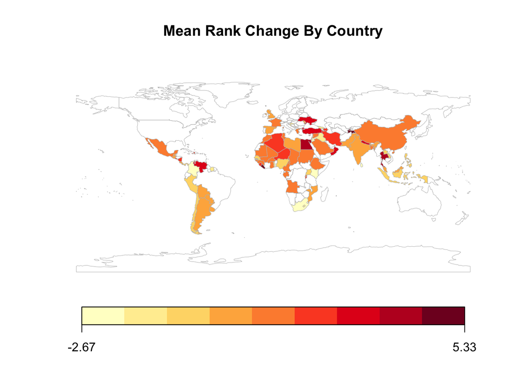

When preparing to investigate our second question about the freedom of women compared to the general population, we utilized the variables Year, Region, Countries, pf_ss, and pf_ss_women. The first three of these variables were previously explained in the paragraph above. pf_ss is the Personal Freedom Security Score for the given country as a whole. pf_ss_women is the Personal Freedom Security Score only for women in said country. Both of these variables take the values from 1-10 measured to one decimal place. These numbers represent the freedom rank from least to most free. In order to start looking into this question, we created a new variable called difference. This variable was created by subtracting pf_ss from pf_ss_women for each entry in the data. A negative difference value represents women having less freedom than the population as a whole and vice versa. The first 15 entries with the difference column calculated can be seen below.

[output not shown]

# RESULTS

##### Question 1

In order to answer our first question about the impact of a country’s at war status on their freedom index scores, I decided to use logistic regression. This type of model is used to model the probability of an event or outcome occurring. In this case, we are predicting the at war status of a country using different freedom indices. First, I separated the dataset into a train and a test set. The train set will be used to make the logistic models. The train data was again separated into two parts, with the first part being used in the creation of the models and the second part being used to calculate the response and evaluate the interaction between the variables selected.

The first logistic regression completed was that of 2-Way interactions. Here, the conflict variable was measured in terms of its interaction with the variables region and rank_change. This regression was computed using the glm function. Once this regression was complete using the first part of the train set, the second part of the train set was used to predict the conflict outcome. This outcome is shown in the frequency table on the left below. This entire process was repeated with No Way interaction. When looking at the values in these respective tables, the values most interesting to us are the ones where the model predicted the outcome correctly. For these tables, these percentage values are located at the top left and bottom right. When looking at the accuracy of the model, we want the majority of the data to be accounted for in these two values. When added together the 2-way interaction model has 71.875% of the data accurately predicted, whereas the No Way interaction model has 68.125% of the data accurately predicted. These percentages are surprisingly close, but the 2-way interaction regression does a slightly better job of predicting the conflict status of a country.

|  | 2 Way Interaction Will be at War | Will Not be at War |
| --- | --- | --- |
| At War | 0.13125 | 0.18125 |
| Not at War | 0.10000 | 0.58750 |

|  | No Way Interaction Will be at War | Will Not be at War |
| --- | --- | --- |
| At War | 0.14375 | 0.16875 |
| Not at War | 0.15000 | 0.53750 |

| Model | Sensitivity | Specificity | FPR | FNR |
| --- | --- | --- | --- | --- |
| 2 Way | 0.42 | 0.8545455 | 0.1454545 | 0.58 |
| No Way | 0.46 | 0.7818182 | 0.2181818 | 0.54 |

Another way to evaluate which of these two interaction models is better is by comparing the sensitivity, specificity, FPR, and FNR statistics of each model, as shown above. Sensitivity represents the ability of the model to make a correct prediction that a country is at war, when the country is actually at war. Specificity is similar and represents the ability of the model to correctly predict that a country isn’t at war when it truly isn’t at war. The false-positive rate (FPR) is when the model says the country is at war when it actually isn’t. The false-negative rate (FNR) is when the model says the country is not at war when it actually is. Given these descriptors, we can determine that both of these models are good at correctly predicting that a country isn’t at war. However, both models lack the ability to correctly predict that a country is at war, with both models being accurate around 50% of the time.

Looking back at our original question, we can say that both of these logistic regression models give us the ability to accurately predict if a country isn’t at war given the rank change and region variables. However, given the relatively high rate of false-negative results, we can’t say with confidence that these models allow us to accurately predict that a country is at war. In terms of the data used, the variables rank change and region are good indicators of a country’s at war status if the country isn’t at war, but are less substantial when it comes to a country not being at war. This conclusion leads us to believe that citizens of a country at war do not necessarily experience less freedom than other countries who aren’t at war. The effects of a country being at war could be counterbalanced by something like an increased employment rate and the implications of that, as suggested in the Introduction section. Due to the high specificity of these models, we can confidently say that countries who are not at war are more likely to see an increase in human freedom, indicated by a decrease in rank, vs countries that are at war.

##### Question 2

The goal with the second question was to determine what variables had an impact on the difference in freedom between women and the overall population. After attempting to find a correlation between the Difference and Region variable, I came to the conclusion that the Region variable didn’t have any type of significant impact on the difference in women’s freedom compared to the population as a whole for a given country. Any model I made had a p-value of 0.99. The p-value represents the chances of getting your results or results more extreme. Any p-value above .05 is generally seen as significant evidence to fail to reject your hypothesis, with the hypothesis, in this case, being that the Region variable correlates with the Difference variable. I repeated this process with the Year variable and came to the same conclusion. Since my original hypothesis of Region and/or Year variables being indicative of the difference variable didn’t lead to any valuable information, I decided to use a method of cross-validation to attempt to determine what variables did impact the difference variable.

I chose to conduct 10 fold cross-validation because this process has low variance compared to other processes, which is important because this dataset is relatively small. When starting this process, I decided to change the variables used to be hf_score, pf_score, pf_ss, pf_ss_women, and Difference. This type of cross-validation requires all numeric values, which is why the country names aren’t included. pf_score was included because the indices that we want to look at are categorized under personal freedom, so the overall score here could be helpful. Since pf_score plays also into the hf_score, that variable was included as well. After I selected the necessary variables, I split the data into train and test sets. The train set was used directly in the 10 fold cross-validation to determine the best alpha and lambda values. These values were then used to make predictions on the test set to determine the mean squared error (MSE). Based on the results found in this step, I selected the appropriate alpha and lambda values that corresponded to the four lowest MSE values, shown below. An alpha value of 0.0 and a lambda value of 0.1679672 are seen to result in the lowest MSE, which means that these values would lead to the best model of this data.

| alpha | lambda | MSE |
| --- | --- | --- |
| 0.0 | 0.1679672 | 51.54823 |
| 0.1 | 0.1212859 | 51.65201 |
| 0.2 | 0.1400931 | 51.64664 |
| 1.0 | 0.1030631 | 51.70164 |

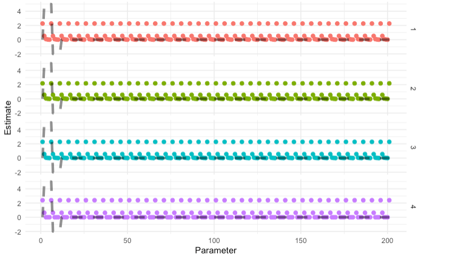

In regards to how this analysis answers our original question, we can conclude that the Year and Region variables have little to no impact on women’s freedom compared to the general population. The Region variable could have gone either way, but the fact that year didn’t have an impact was surprising. I would assume that as time went on, countries would become more progressive and would award women more rights and freedom. However, this wasn’t seen to be the case as the Year variable had no correlation with the difference values. We would have expected the difference values to trend towards higher positive numbers as the years went on, but this wasn’t the case. The opposite didn’t occur either, so this variable was deemed unimportant when grouped with the difference variable. In terms of the variables I ended up using in the 10 fold cross-validation, these variables seem to be indicative of the difference value. A higher hf_score overall would be indicative of women having equal or more freedom compared to the overall population. This outcome makes sense since hf_score is a country’s overall freedom score. Although this was expected, our results indicate that women’s freedom plays a substantial role in determining the freedom of a country.

# CONCLUSION

At the beginning of this analysis we had the goal of answering the question, “Can we predict whether a country is at war based on rank change data and other indices?” After conducting logistic regression with different interactions, we were able to determine that the rank change and region variables are good indicators of a country’s war status if the country isn’t at war. These variables are less accurate indicators of a country’s war status if they are at war, with only accuracy of around 50%. This conclusion leads us to believe that citizens of a country at war do not necessarily experience less freedom than other countries who aren’t at war. Due to the high specificity of these models created, we can also confidently say that countries who are not at war are more likely to see an increase in human freedom, indicated by a decrease in rank, vs countries that are at war. These results are important because they debunk the hypothesis that citizens of at war countries are likely to experience less freedom than other countries who are at peace. This misconception could lead people to make uninformed decisions regarding relocating themselves or their businesses. Happier citizens lead to increases in consumerism and community involvement, which have a significant impact on businesses. Knowing the facts here would lead to accurately informed decision making.

The second question we had the goal of answering was “What factors influence the difference between women’s freedom scores and the general population’s freedom scores in this index?”. The results of this analysis lead us to the surprising conclusion that the year variable had little to no impact on whether women experienced more or equal freedom compared to the general population. Although this discovery is surprising, this outcome could be due to the fact that our dataset only went from 2008 to 2017. I think the next step for this analysis would be including earlier data, specifically data from the 1900’s. Including these earlier values would allow for the relationship between these two variables to be explored more fully. Another route that could be taken would be to include more data on women, rather than just their overall freedom score. Specific variables relating to equal employment opportunity, voting rights, and other indicators would be interesting to explore in-depth. Even without those additional variables, the results obtained from this analysis do a good job of highlighting the fact that women are generally less free than the overall population.

For both of these questions that were explored, I think it would be important to conduct a similar analysis with the addition of political indices. The Human Freedom Index didn’t include variables related to political freedom since the freedom level of each type of government is very subjective. However, I think political data would be an important part of this analysis because different political systems definitely have an impact on the rights of citizens. These political indicators could potentially explain some of the variability in the results from our question regarding war, because different types of governments probably approach wartime activities in drastically different ways.

In general, conducting analysis on this type of data is important in understanding the difference between countries and regions around the world and how these differences impact the freedom of their citizens.